# Pseudobulk Differential Expression Analysis of Intestinal IEL and LPL Compartments: Crohn’s Disease versus Control

Bioinformatics Analysis Service 2026-08-17

# 1. Executive Summary

This report describes the pseudobulk differential expression (DE) analysis performed on the compartment-specific reclustered IEL and LPL single-cell RNA-seq data, comparing Crohn’s disease (CD) versus control (Control) tissue within each statistically eligible cell population.

The analytical workflow included:

- aggregation of single-cell counts into per-donor, per-cell-type pseudobulk samples
- a programmatic QC gate requiring at least 2 donors per condition and at least 10 cells per pseudo-sample, blocking any comparison that fails these criteria rather than proceeding silently
- DESeq2 differential expression testing (`~ condition` design, `Control` as reference level) with `apeglm` log2 fold-change shrinkage
- diagnostic visualization (volcano plots, `plotMA`, top-DEG heatmaps) and compositional cross-referencing against the upstream cell-type annotation

Six cell populations passed the initial QC gate. Five populations were carried through to DE testing after applying an additional biological interpretability criterion: three in IEL (IEL-Cytotoxic-TRM-like, IEL-TH17, IEL-Cycling-T-cells) and two in LPL (LPL-Cytotoxic-TRM-like, LPL-Treg). Across these five comparisons, differential expression results converge on two recurrent gene-level patterns identified at the compartment-resolved level in this analysis: recurrent up-regulation of *GNLY* in CD across four of five analyzed populations, and a stress-response/glucocorticoid-responsive gene module (*FKBP5*, *TSC22D3*, *TXNIP*, *ZFP36L2*, *NFKBIA*, *DUSP2*) across every cell type analyzed. The latter provides direct, gene-level support for the “response to corticosteroid/glucocorticoid” pathway signal flagged as provisional in the companion GSEA report.

# 2. Statistical Design

## 2.1 Pseudobulk construction and QC gate

For each cell type, single-cell counts were aggregated by donor to form pseudobulk samples. A comparison was only carried forward to DESeq2 testing if it satisfied, for both conditions independently:

- at least 2 donors per condition group
- at least 10 cells per pseudo-sample

This gate is enforced programmatically (`stop()` on failure) rather than as a post-hoc filter, so that no comparison built on an under-powered donor structure is silently reported.

## 2.2 DESeq2 model

```
design = ~ condition
condition releveled with "Control" as reference
contrast = c("condition", "CD", "Control")
lfcShrink(type = "apeglm")
```

Positive log2 fold change and positive Wald statistic indicate higher expression in CD relative to Control, consistently across all five comparisons (the releveling step is executed independently inside each per-cell-type loop iteration, so the contrast direction cannot be inconsistent between cell types).

## 2.3 Significance thresholds

Genes were called significant at `padj < 0.05` and `|log2FoldChange| > 1`, consistent with the thresholds used to define the significant/DEG gene sets feeding into the companion GSEA analysis.

# 3. Eligible Cell Types

**IEL compartment**

```
Eligible cell types: IEL-Cycling-T-cells, IEL-Cytotoxic-TRM-like, IEL-TH17
```

**LPL compartment**

```
Eligible cell types: LPL-Cytotoxic-TRM-like, LPL-Treg, LPL-Other-CD4-T-cells
```

`LPL-Other-CD4-T-cells` passed the minimum QC requirements but was excluded from downstream DE analysis due to its heterogeneous transcriptional composition and lack of a clearly defined biological comparison target.

## 3.1 Donor structure underlying every comparison

Both compartments draw on the same four donors, split 2 CD / 2 Control:

| Donor | Condition | Disease state label |
| --- | --- | --- |
| 1425 | Control | normal |
| 7420 | Control | normal |
| 1813 | CD | mixed inflamed/non-inflamed (LPL); predominantly non-inflamed (IEL) |
| 1818 | CD | mixed inflamed/non-inflamed |

Every DESeq2 comparison in this report therefore rests on **exactly the minimum donor count** the QC gate permits (2 vs 2). This is the single most important statistical caveat governing the entire pseudobulk analysis and is revisited in Section 8.1.

[output not shown]

**Table 1.** Summary of the differential expression analysis performed for each eligible cell population. *Genes tested* indicates the number of genes retained after pre-filtering and included in the DESeq2 statistical model. Significant DEGs were defined as genes with an adjusted *P* value < 0.05 and an absolute log2 fold change > 1.

# 4. IEL Compartment: Differential Expression Results

## 4.1 IEL-Cycling-T-cells

**Volcano plot**

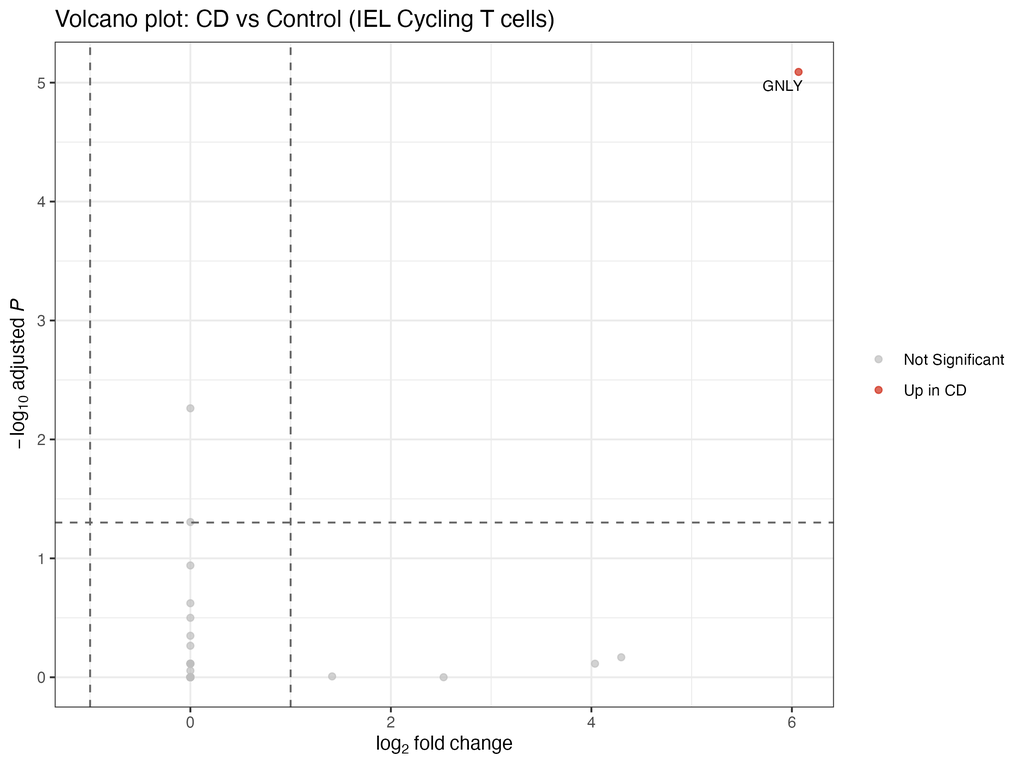

**MA plot (shrunk LFC)**

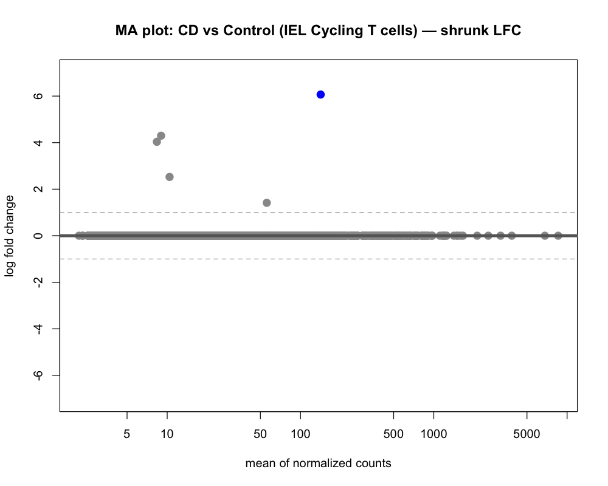

**Top 30 DEGs (including non-significant top-ranked genes)**

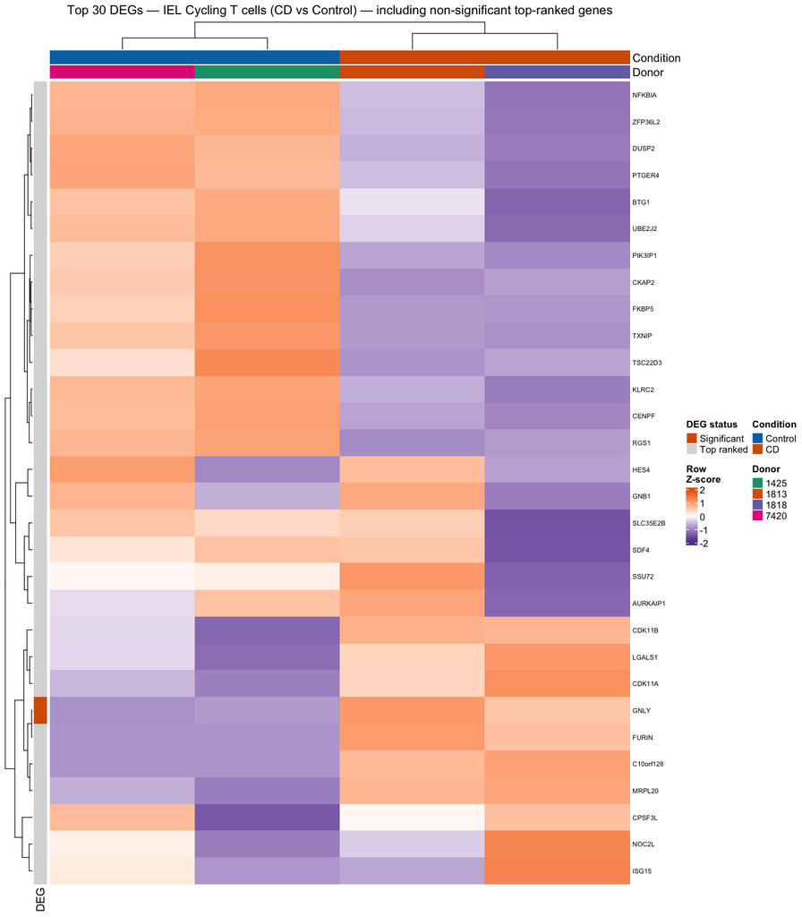

**Interpretation.** Only one gene reaches significance: *GNLY* (granulysin), strongly up in CD. This is consistent with the small leading-edge sizes observed for this population in the companion GSEA analysis, and with this being the smallest of the five eligible cell types by cell number. The `plotMA` shows apeglm shrinkage behaving as expected: the bulk of genes are pulled tightly around LFC = 0, with only a handful of low-to-moderate count genes retaining appreciable fold change. The top-30 heatmap shows the glucocorticoid-responsive module (*NFKBIA*, *ZFP36L2*, *DUSP2*, *PTGER4*, *FKBP5*, *TXNIP*, *TSC22D3*) consistently higher in Control than CD across both donors per condition, despite none of these genes individually crossing the significance threshold here — a pattern-level signal below individual-gene significance, consistent with why GSEA (Section 4.3 of the companion report) detects this axis even where single-gene DE testing does not.

## 4.2 IEL-Cytotoxic-TRM-like

**Volcano plot**

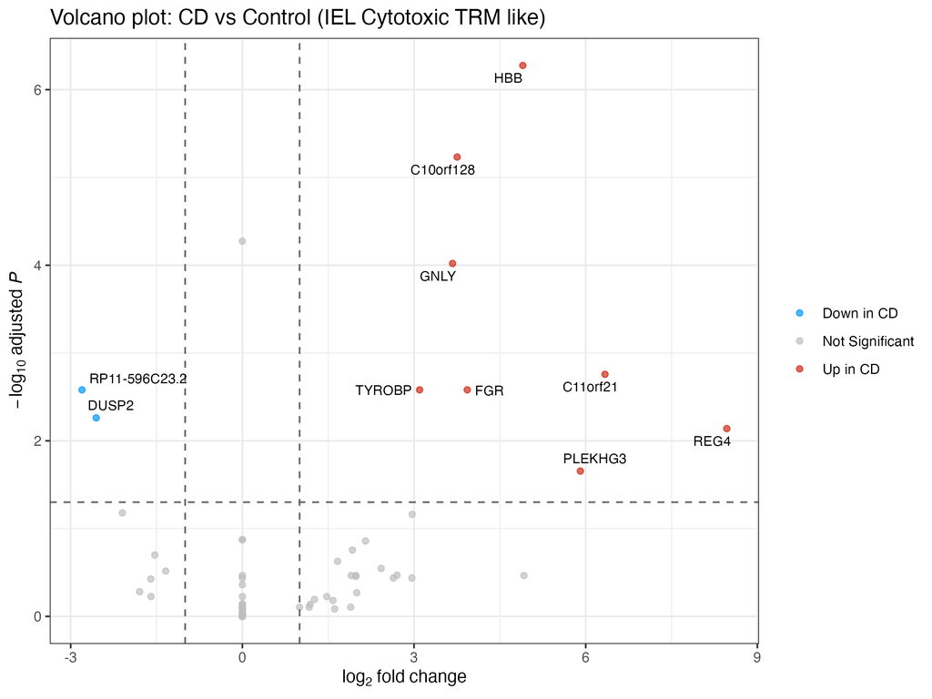

**MA plot (shrunk LFC)**

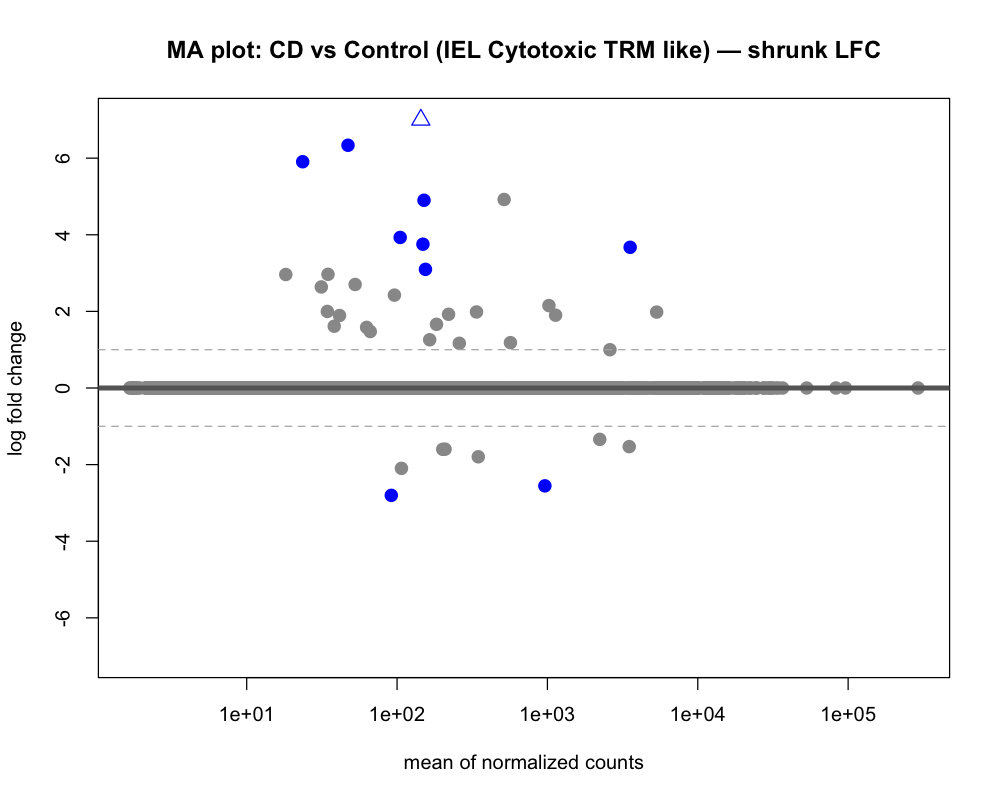

**Top 30 DEGs (including non-significant top-ranked genes)**

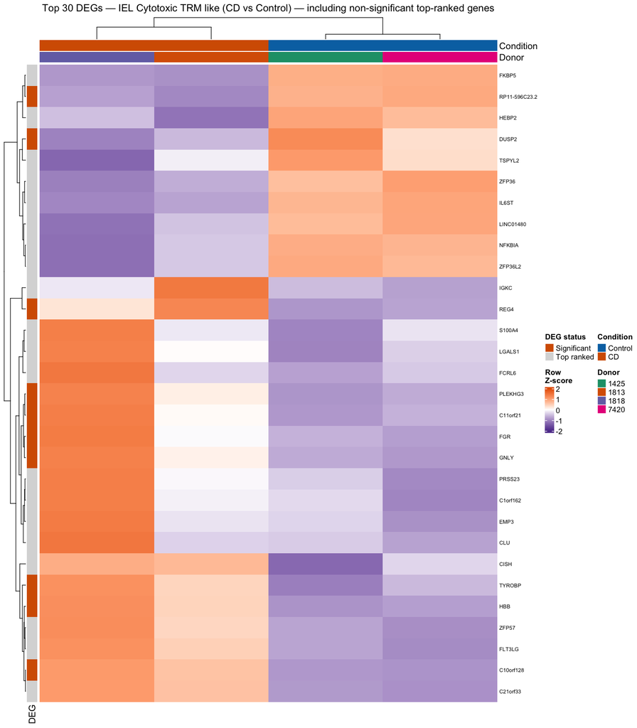

**Interpretation.** This comparison shows the second-largest number of significant DEGs among the five (visually: 8 up — *HBB*, *C10orf128*, *GNLY*, *TYROBP*, *FGR*, *C11orf21*, *REG4*, *PLEKHG3* — and 2 down — *RP11-596C23.2*, *DUSP2*). Two findings require explicit caution rather than direct biological interpretation:

- **HBB** (hemoglobin beta) among the top up-regulated genes is a recognized signature of ambient erythrocyte RNA contamination in droplet-based scRNA-seq, not a plausible T-cell transcriptional program.
- **REG4** (an epithelial antimicrobial peptide gene) is biologically implausible as a genuine T-cell transcript and is more consistent with ambient contamination from adjacent epithelial cells — physically expected given the intraepithelial localization of this compartment.

*TYROBP* and *FGR* (myeloid signaling adaptors) up in CD are more ambiguous: they could reflect genuine expression in NK-like tissue-resident cytotoxic cells (documented in some cytotoxic T/NK-like populations) or residual ambient signal; this cannot be resolved from pseudobulk data alone (Section 8.2). The top-30 heatmap again shows the corticosteroid-responsive module (*FKBP5*, *NFKBIA*, *ZFP36L2*, *ZFP36*, *IL6ST*) elevated in Control relative to CD.

## 4.3 IEL-TH17

**Volcano plot**

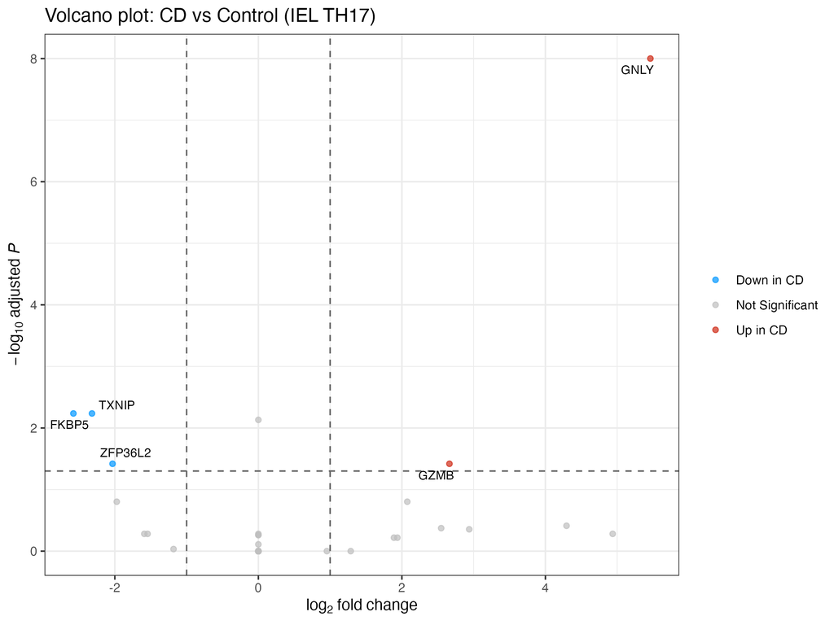

**MA plot (shrunk LFC)**

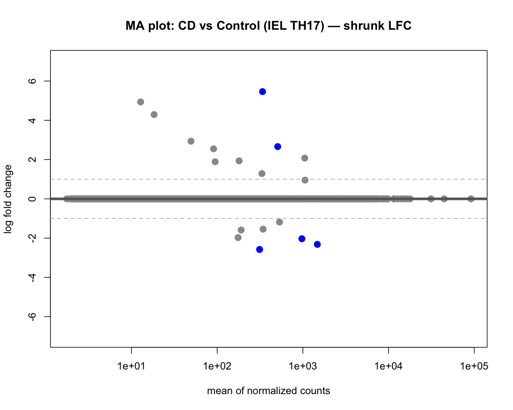

**Top 30 DEGs (including non-significant top-ranked genes)**

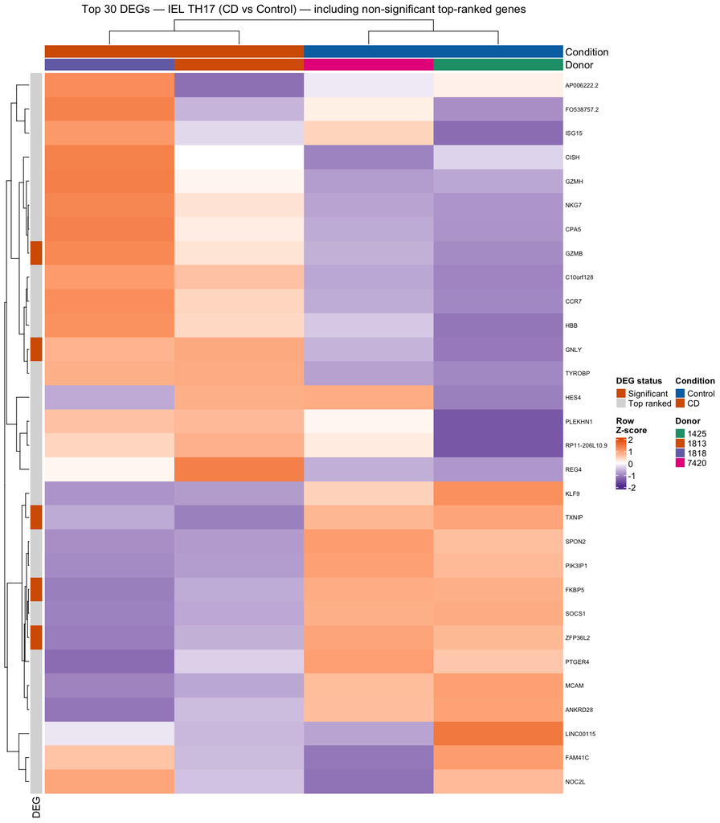

# 5. LPL Compartment: Differential Expression Results

## 5.1 LPL-Cytotoxic-TRM-like

**Volcano plot**

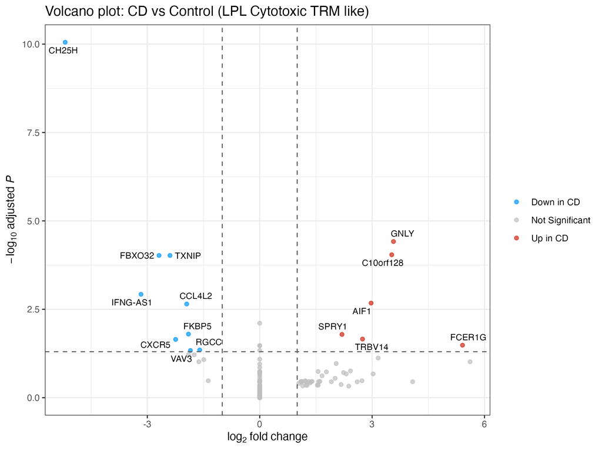

**MA plot (shrunk LFC)**

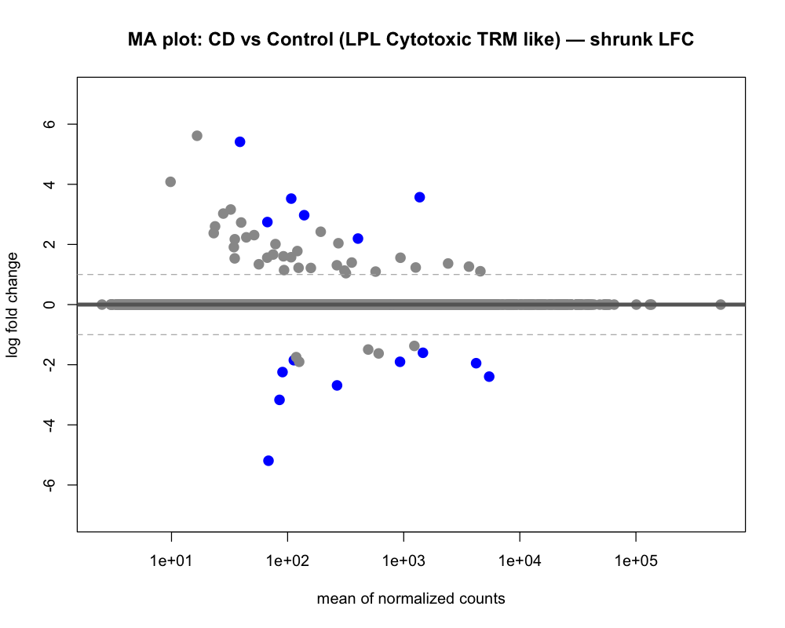

**Top 30 DEGs (including non-significant top-ranked genes)**

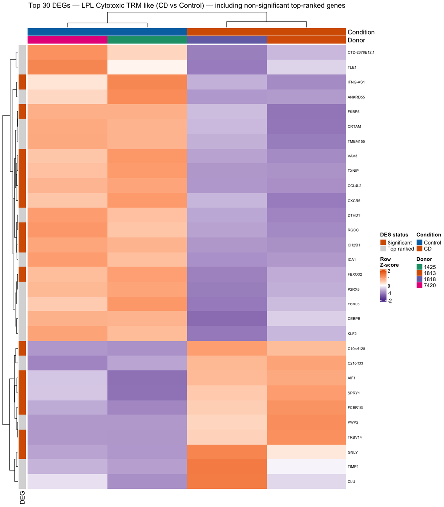

- **IFNG-AS1** (a long non-coding RNA reported to positively regulate *IFNG* transcription) is significantly *down* in CD, which sits in apparent tension with the Hallmark Interferon Gamma Response signature being *up* in CD for this same population. These are not necessarily contradictory (the lncRNA is not itself a member of the Hallmark gene set, and negative-feedback dynamics are plausible), but the tension should be resolved by inspecting IFN-γ pathway leading-edge genes directly rather than assumed away.
- **CH25H** (an interferon-stimulated gene with immunomodulatory, oxysterol-mediated function) is the single most significant gene in this entire report and is down in CD — again notable alongside an up-regulated IFN-γ response signature, and worth the same leading-edge-level reconciliation.

The corticosteroid-responsive module (*FKBP5*, *TXNIP*) recurs here as well, consistent with every other comparison in this report.

## 5.2 LPL-Treg

**Volcano plot**

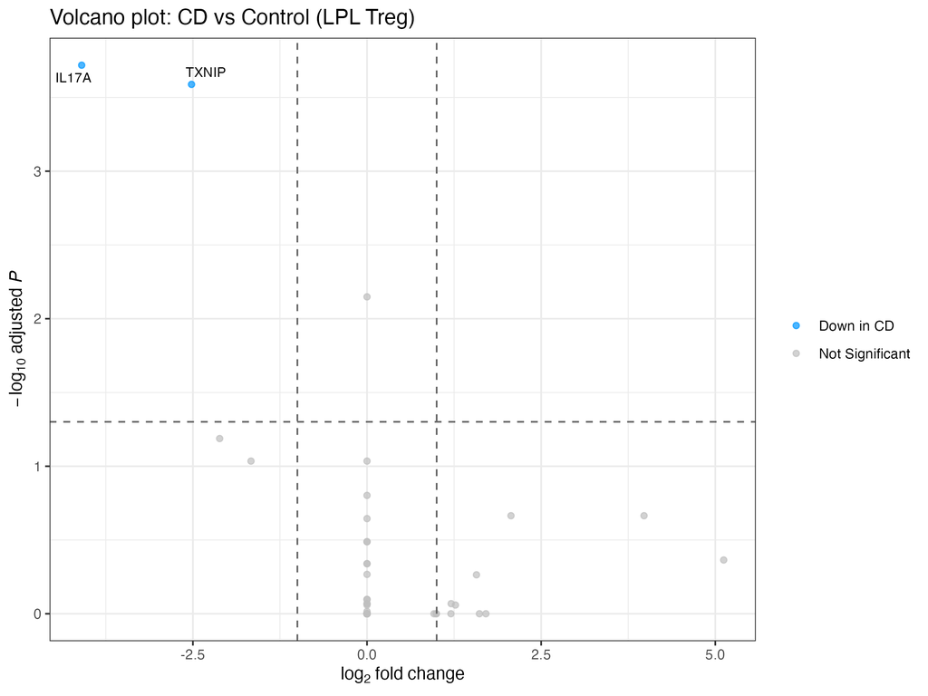

**MA plot (shrunk LFC)**

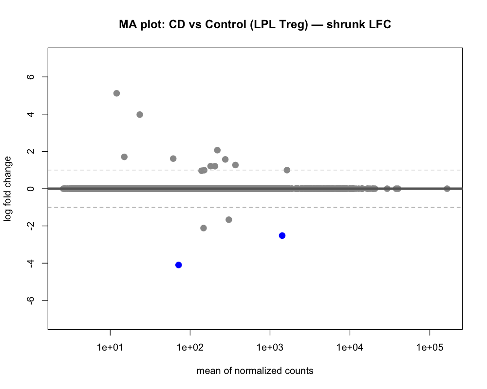

**Top 30 DEGs (including non-significant top-ranked genes)**

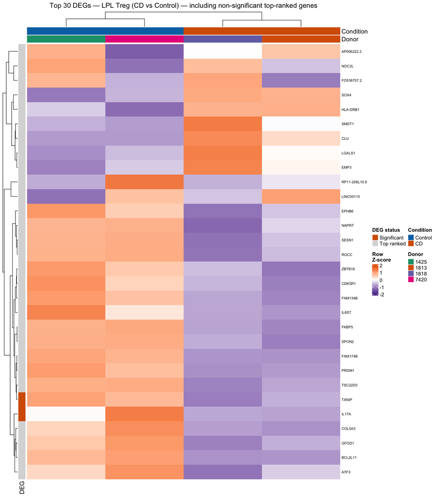

# 6. Compositional Context

## 6.1 Compartment composition by condition

**IEL — proportions by disease and condition/donor**

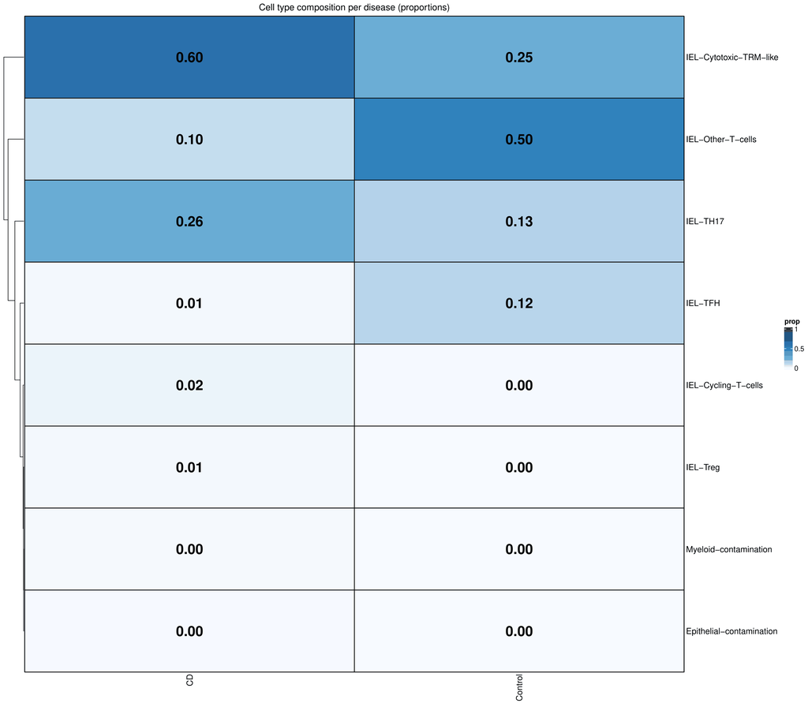

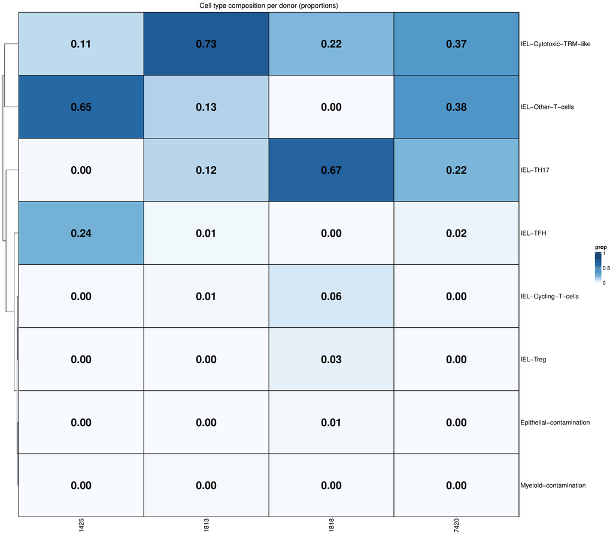

**LPL — proportions by disease and donor**

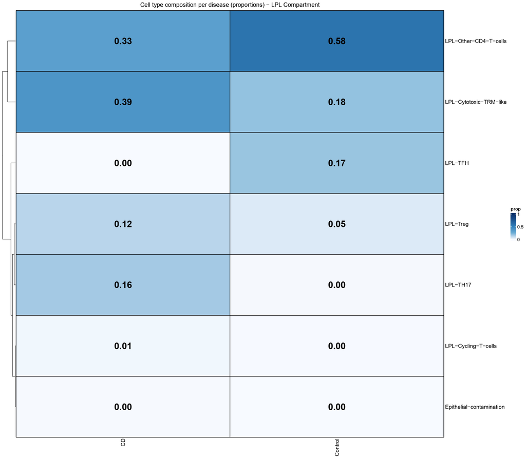

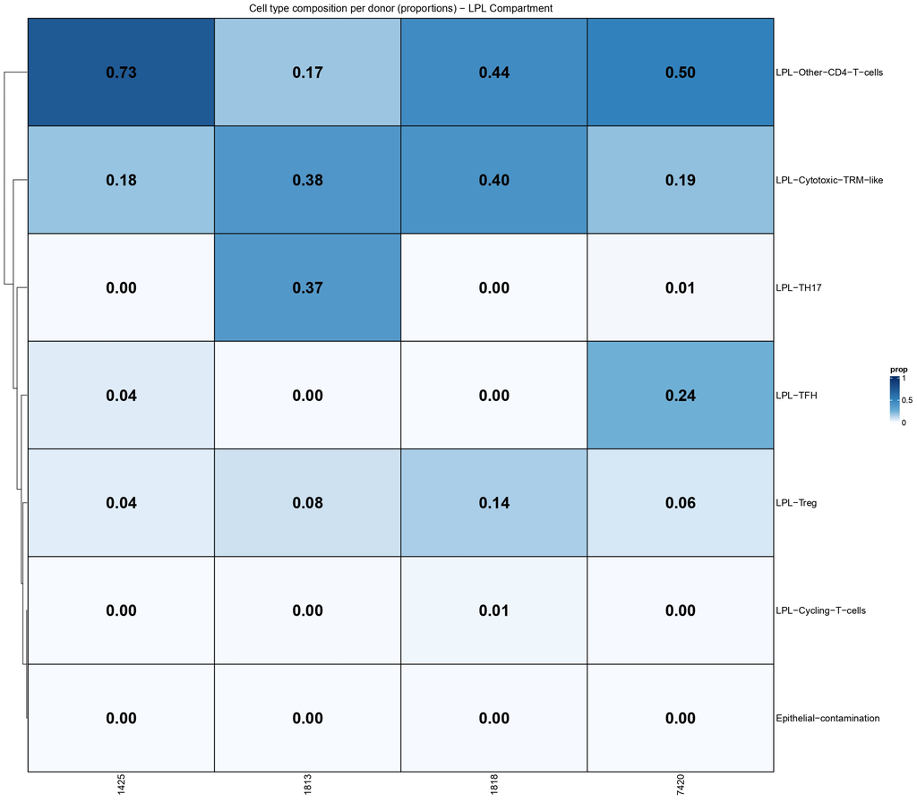

## 6.2 Cross-compartment compositional concordances

Two compositional shifts are directionally concordant across both compartments and independently support the DE/GSEA findings above:

| Cell type | IEL: CD vs Control | LPL: CD vs Control | Direction |
| --- | --- | --- | --- |
| TFH | 1% vs 12% | 0% vs 17% | Concordant loss in CD, both compartments |
| Cytotoxic-TRM-like | 60% vs 25% | 39% vs 18% | Concordant relative expansion in CD, both compartments |

One compositional shift is **not** concordant with the a priori expectation set by the companion GSEA report’s citation of reduced Treg proportion in CD (Jaeger et al. 2021):

| Cell type | IEL: CD vs Control | LPL: CD vs Control |
| --- | --- | --- |
| Treg | 1% vs 0% | 12% vs 5% |

Both compartments show a *higher*, not lower, Treg proportion in CD by this pipeline’s transcriptional clustering. This is flagged explicitly as an open discrepancy in Section 8.4 rather than reconciled by assumption.

# 7. Comparison with GSEA Results

| Pseudobulk DE finding | Corresponding GSEA finding | Relationship |
| --- | --- | --- |
| Glucocorticoid-responsive module (FKBP5, TSC22D3, TXNIP, ZFP36L2, NFKBIA, DUSP2) down in CD, all 5 cell types | “Response to corticosteroid/glucocorticoid” down, 3/5 cell types (GO:BP) | Direct gene-level confirmation; resolves the “not independently verified” caveat (Section 10.5, GSEA report) |
| GNLY up in CD, 4/5 cell types | Cytotoxic/granzyme-associated GO:BP and Hallmark terms up across IEL/LPL cytotoxic populations | Consistent individual driver gene |
| GZMB up in IEL-TH17 | Hallmark Inflammatory Response / IFN-γ Response up, IEL-TH17 | Consistent individual driver gene |
| IFNG-AS1, CH25H down in CD, LPL-Cytotoxic-TRM-like | Hallmark Interferon Gamma Response up, same population | Apparent tension; requires leading-edge reconciliation (Section 5.1) |
| TXNIP down in CD, LPL-Treg | IL2-STAT5 Signaling up (Hallmark), LPL-Treg | Compatible (TXNIP is a negative regulator of glucose uptake/STAT signaling contexts) but not directly tested |

# 8. Limitations

## 8.1 Minimum-donor statistical power

### Limitations of the pseudobulk analysis

Every DESeq2 comparison in this report is based on **2 CD and 2 Control donors**. Although **at least three biological replicates per condition are generally recommended** for robust RNA-seq differential expression analysis, only two donors per group were available after quality-control filtering and were therefore retained for the analysis. DESeq2 remains computationally applicable with two replicates, although dispersion estimation and inference are less reliable.

For this reason, **gene set enrichment analysis (GSEA)** constitutes the primary biological readout of this study. Because GSEA evaluates the complete ranked gene list rather than relying exclusively on individual gene significance thresholds, it can provide a more informative view of coordinated biological changes in low-powered settings such as this. Consequently, the pseudobulk differential expression results should be interpreted primarily as **gene-level support for pathway-level alterations identified by GSEA**, rather than as an independent discovery layer with equivalent statistical weight.

## 8.2 Candidate ambient-RNA contamination genes

*HBB* and *REG4* among the top DEGs in IEL-Cytotoxic-TRM-like are better explained by ambient erythrocyte and epithelial RNA contamination, respectively, than by genuine T-cell biology. *TYROBP*, *FGR*, *FCER1G*, and *AIF1* (myeloid signaling adaptors) recurring across cytotoxic populations are more ambiguous and cannot be resolved as genuine versus ambient from pseudobulk data alone. Recommended follow-up: cross-check these genes’ expression specificity against the myeloid-contamination cluster already identified during upstream QC (Subsetting Compartment report), and consider explicit exclusion or flagging of established ambient-RNA marker genes before final reporting.

## 8.4 Treg compositional direction discrepancy

As detailed in Section 6.2, this dataset shows Treg proportion *increasing*, not decreasing, in CD in both compartments — in tension with the Jaeger et al. (2021) flow cytometry finding of reduced CD25<sup>hi</sup> CD4⁺ T cells in CD, cited as supporting context in the companion GSEA report’s interpretation of the LPL-Treg IL2-STAT5 signal (Section 5.2, GSEA report). A plausible reconciliation is that this pipeline’s transcriptionally-defined Treg cluster and the original paper’s CD25<sup>hi</sup> flow cytometry gate are not measuring identical populations, but this has not been verified and should be treated as an open discrepancy, not assumed away.

# 9. Reproducibility

Environment:

- R version: 4.6.0
- DESeq2 version: 1.52.0
- apeglm version: 1.34.0

All intermediate DE result objects are stored under:

`objects/pseudobulk/`

All visual outputs under:

IEL Compartment: `results/plots/Pseudobulk_IEL/`  
LPL Compartment: `results/plots/Pseudobulk_LPL/`

# 10. Deliverables

- Pseudobulk DESeq2 result tables (`res`, `res_shrunk`) per cell type, per compartment
- Volcano plots, MA plots, top-ranked gene expression heatmaps per cell type (this report)
- Compositional proportion tables (cell type × condition / disease / donor) for both compartments

# 11. Conclusion